# Lab 8: MATH 4753

## Task 3

### Population mean

```r
set.seed(39)
sam=rnorm(25,mean=25,sd=10)
mu = 25
mu
```

```
## [1] 25
```

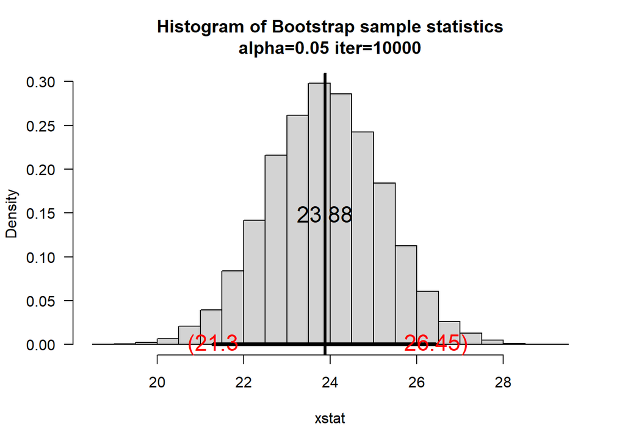

```r
myboot2(sam, iter = 10000, alpha = 0.05)
```

The point estimate is 1.12 lower than the population value.

Yes, the population mean, 25, falls within the confidence interval of 21.3 to 26.45.

```r
set.seed(30)
sam=rchisq(20,df=3)
v = 3
v
```

```
## [1] 3
```

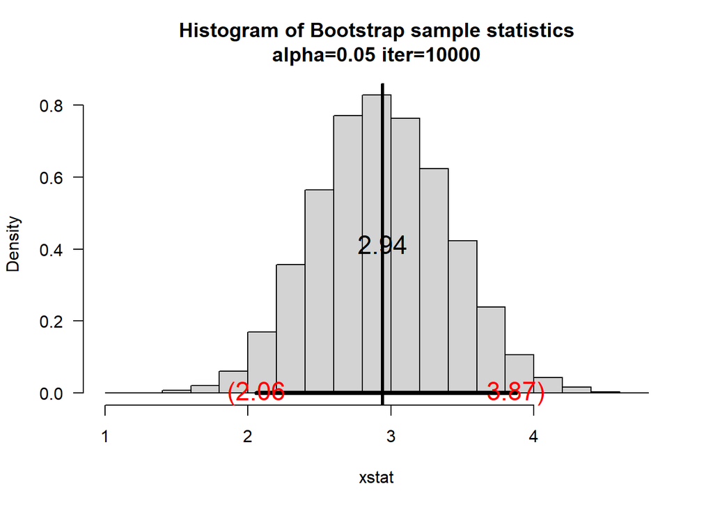

```r
myboot2(sam, iter = 10000, alpha = 0.05)
```

The point estimate is 0.06 lower than the population value.

Yes, the population mean, 3, falls within the confidence interval 2.06 to 3.87.

```r
set.seed(40)
sam=rgamma(30,shape=2,scale=3)
alphabeta = 2*3
alphabeta
```

```
## [1] 6
```

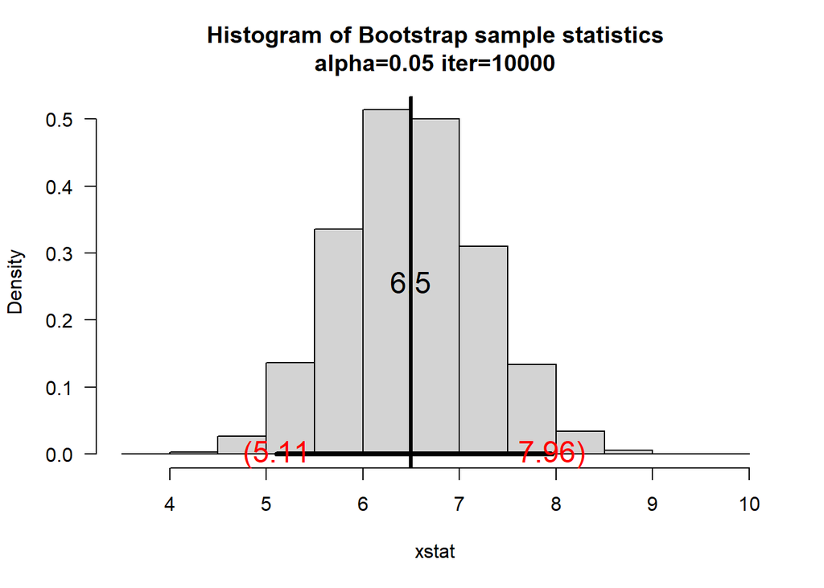

```r
myboot2(sam, iter = 10000, alpha = 0.05)
```

The point estimate is 0.5 higher than the population value.

Yes, the population mean, 6, falls within the confidence interval, 5.11 to 7.96.

```r
set.seed(10)
sam=rbeta(20,shape1=3,shape2=4)
mean = 3/(3+4)
mean
```

```
## [1] 0.4285714
```

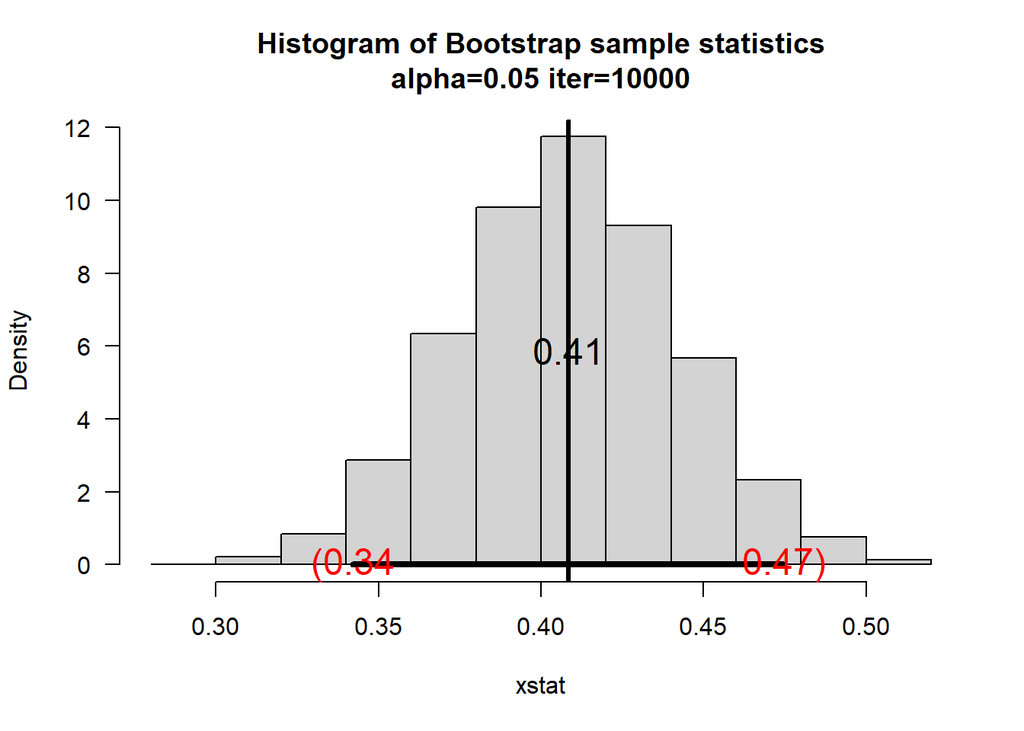

```r
myboot2(sam, iter = 10000, alpha = 0.05)
```

The point estimate is .0186 lower than the population value.

Yes, the population mean, 0.4286, falls within the confidence interval, 0.34 to 0.47.

### Population variance

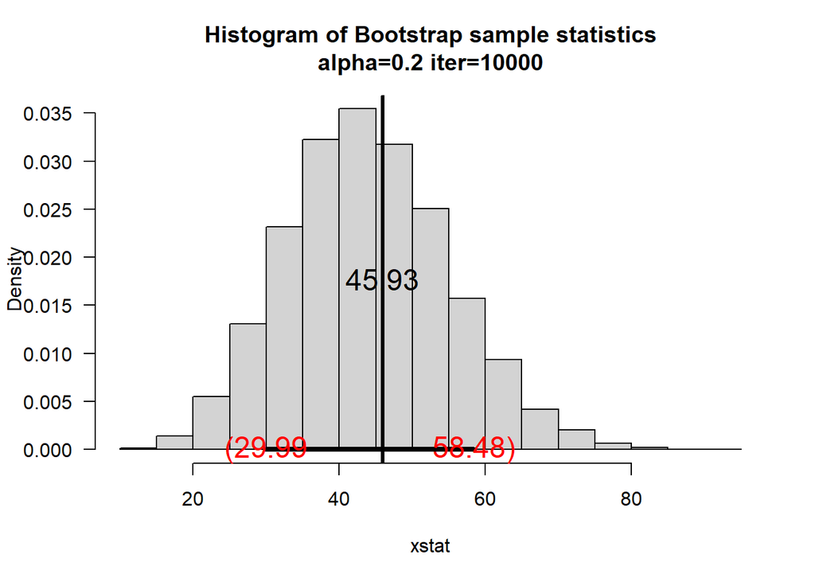

```r
set.seed(39)
sam=rnorm(25,mean=25,sd=10)
myboot2(sam, iter = 10000, alpha = 0.20, fun = "var")
```

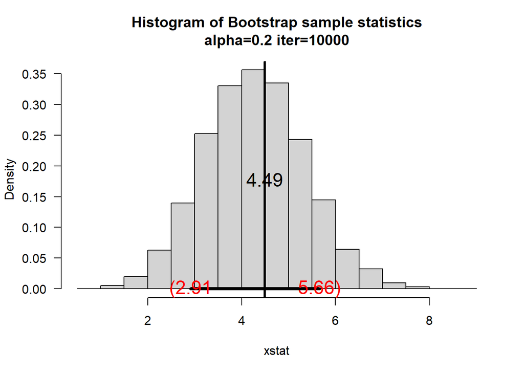

```r
set.seed(30)
sam=rchisq(20,df=3)
myboot2(sam, iter = 10000, alpha = 0.20, fun = "var")
```

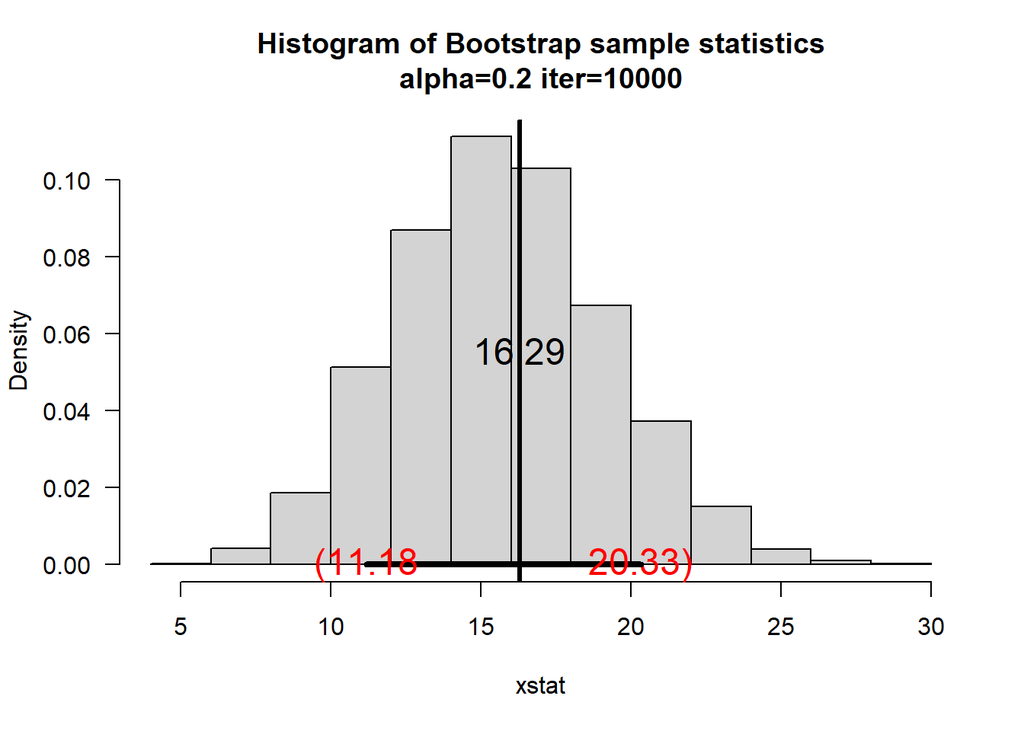

```r
set.seed(40)
sam=rgamma(30,shape=2,scale=3)
myboot2(sam, iter = 10000, alpha = 0.20, fun = "var")
```

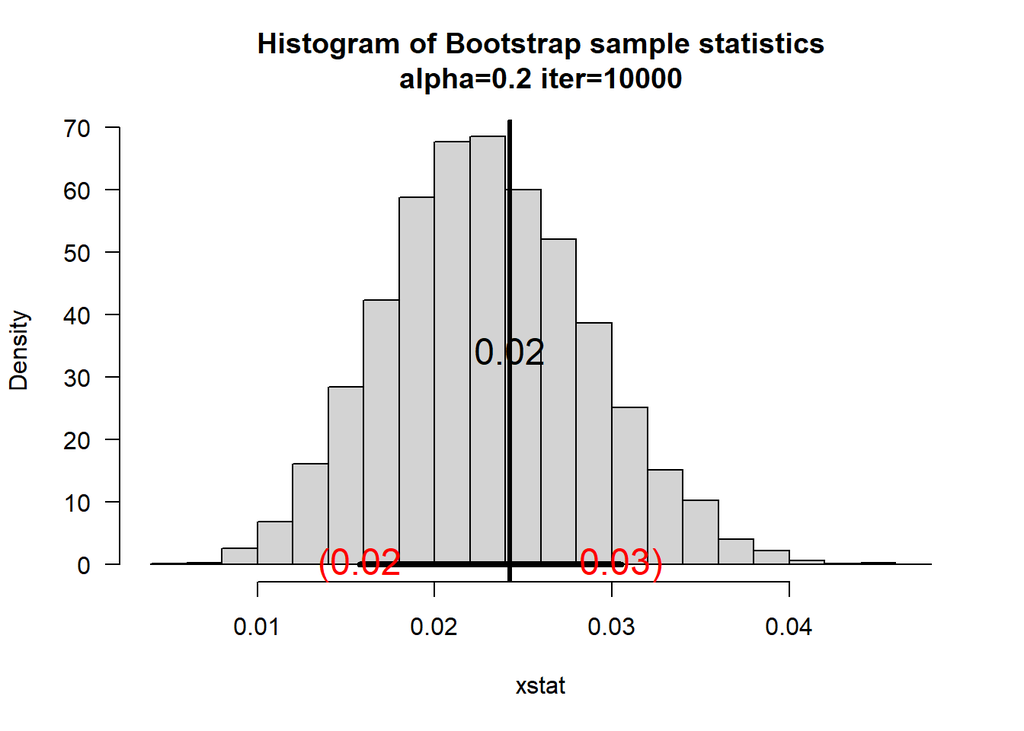

```r
set.seed(10)
sam=rbeta(20,shape1=3,shape2=4)
myboot2(sam, iter = 10000, alpha = 0.20, fun = "var")
```

## Task 4

Adjusting myboot2:

```r
myboot2task4<-function(iter=10000,x,fun="mean",alpha=0.05,cx=1.5,...){  #Notice where the ... is repeated in the code
n=length(x)   #sample size

y=sample(x,n*iter,replace=TRUE)
rs.mat=matrix(y,nr=n,nc=iter,byrow=TRUE)
xstat=apply(rs.mat,2,fun) # xstat is a vector and will have iter values in it
ci=quantile(xstat,c(alpha/2,1-alpha/2))# Nice way to form a confidence interval
# A histogram follows
# The object para will contain the parameters used to make the histogram
para=hist(xstat,freq=FALSE,las=1,
main=paste("Histogram of Bootstrap sample statistics","\n","alpha=",alpha," iter=",iter,sep=""),
...)

#mat will be a matrix that contains the data, this is done so that I can use apply()
mat=matrix(x,nr=length(x),nc=1,byrow=TRUE)

#pte is the point estimate
#This uses whatever fun is
pte=apply(mat,2,fun)
abline(v=pte,lwd=3,col="Black")# Vertical line
segments(ci[1],0,ci[2],0,lwd=4)      #Make the segment for the ci
text(ci[1],0,paste("(",round(ci[1],2),sep=""),col="Red",cex=cx)
text(ci[2],0,paste(round(ci[2],2),")",sep=""),col="Red",cex=cx)

# plot the point estimate 1/2 way up the density
text(pte,max(para$density)/2,round(pte,2),cex=cx)

invisible(list(ci=ci,fun=fun,x=x, xstat = xstat))# Some output to use if necessary
}
```

```r
sam=c(1,1,1,2,2,2,2,3,3,3,4,4)
myboot = myboot2task4(x=sam, fun="median")
```

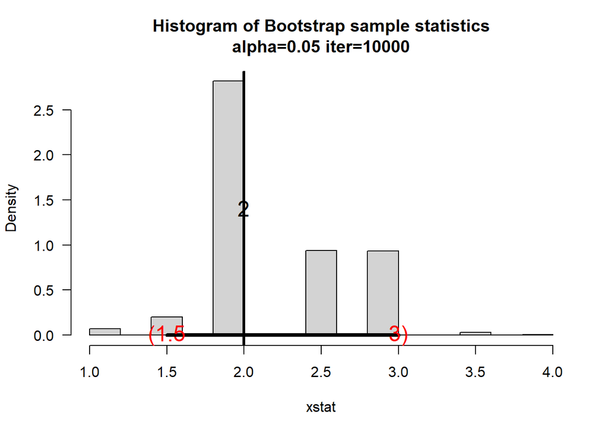

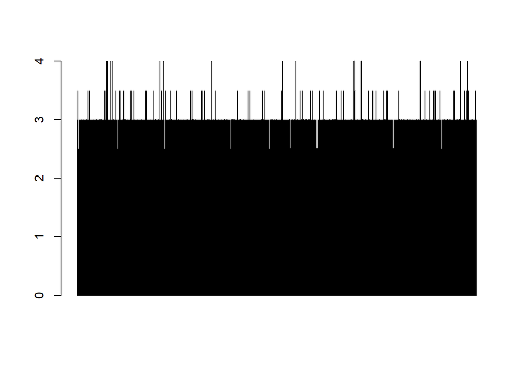

```r
xstat = myboot$xstat
barplot(xstat)
```

The bootstrap interval estimate for the population median is 1.5 to 3.

## Task 5

Making the function population mean/median

```r
meandian = function(x){
  mean(x)/median(x)

  }
```

### The 95% interval estimates

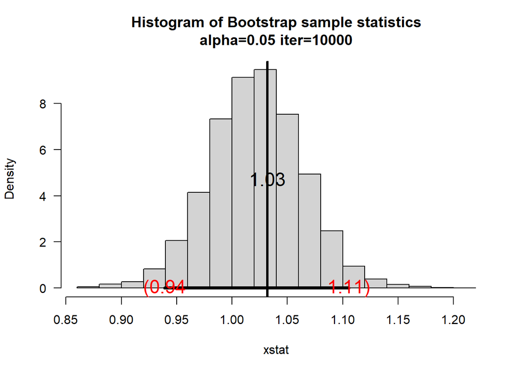

```r
set.seed(39)
sam=rnorm(25,mean=25,sd=10)
myboot2(sam, iter = 10000, alpha = 0.05, fun = "meandian")
```

The 95% interval estimate for the population mean/median is 0.94 to 1.11.

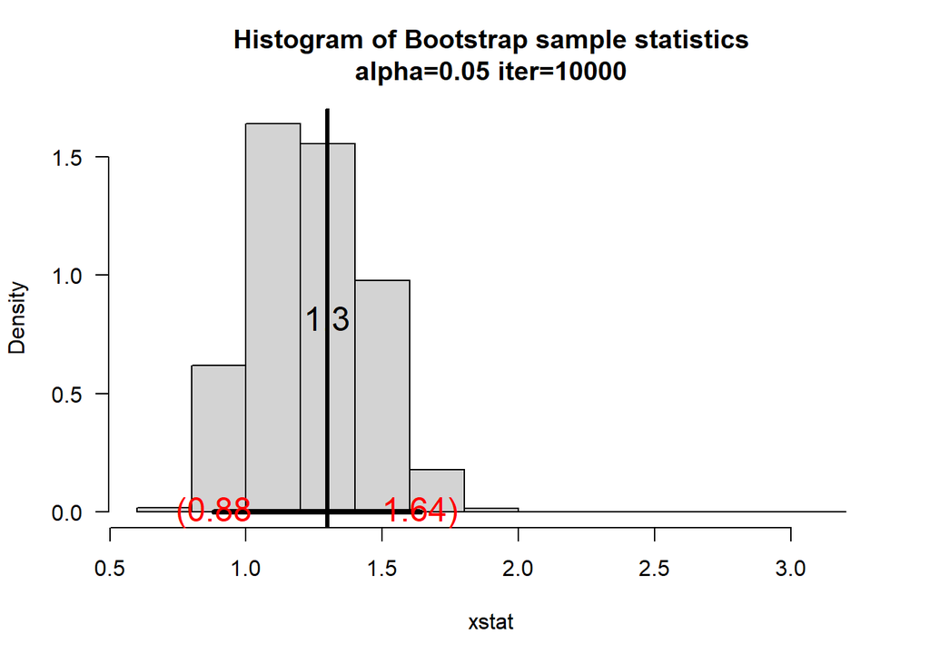

```r
set.seed(30)
sam=rchisq(20,df=3)
myboot2(sam, iter = 10000, alpha = 0.05, fun = "meandian")
```

The 95% interval estimate for the population mean/median is 0.88 to 1.64.

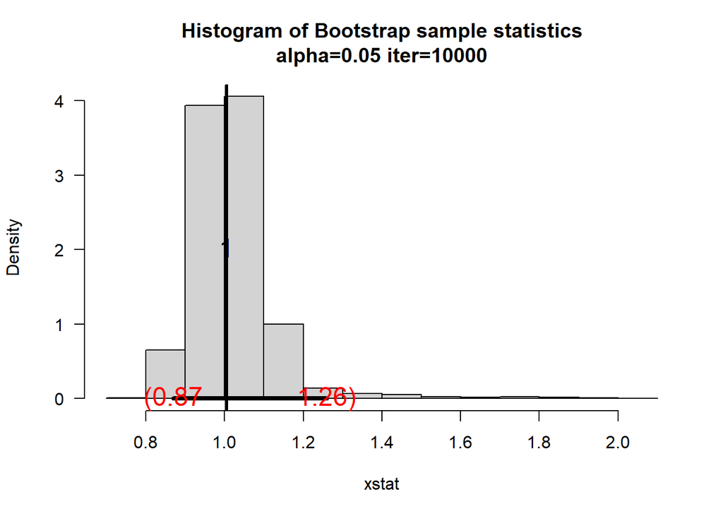

```r
set.seed(40)
sam=rgamma(30,shape=2,scale=3)
myboot2(sam, iter = 10000, alpha = 0.05, fun = "meandian")
```

The 95% interval estimate for the population mean/median is 0.87 to 1.26.

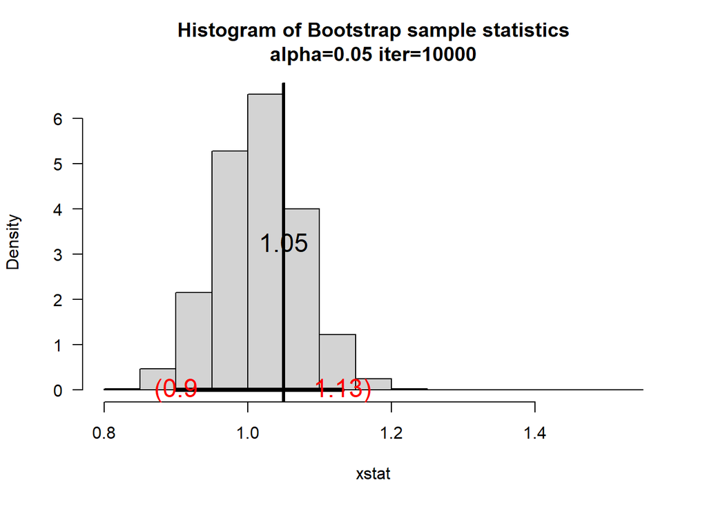

```r
set.seed(10)
sam=rbeta(20,shape1=3,shape2=4)
myboot2(sam, iter = 10000, alpha = 0.05, fun = "meandian")
```

The 95% interval estimate for the population mean/median is 0.9 to 1.13.

### The 70% interval estimates

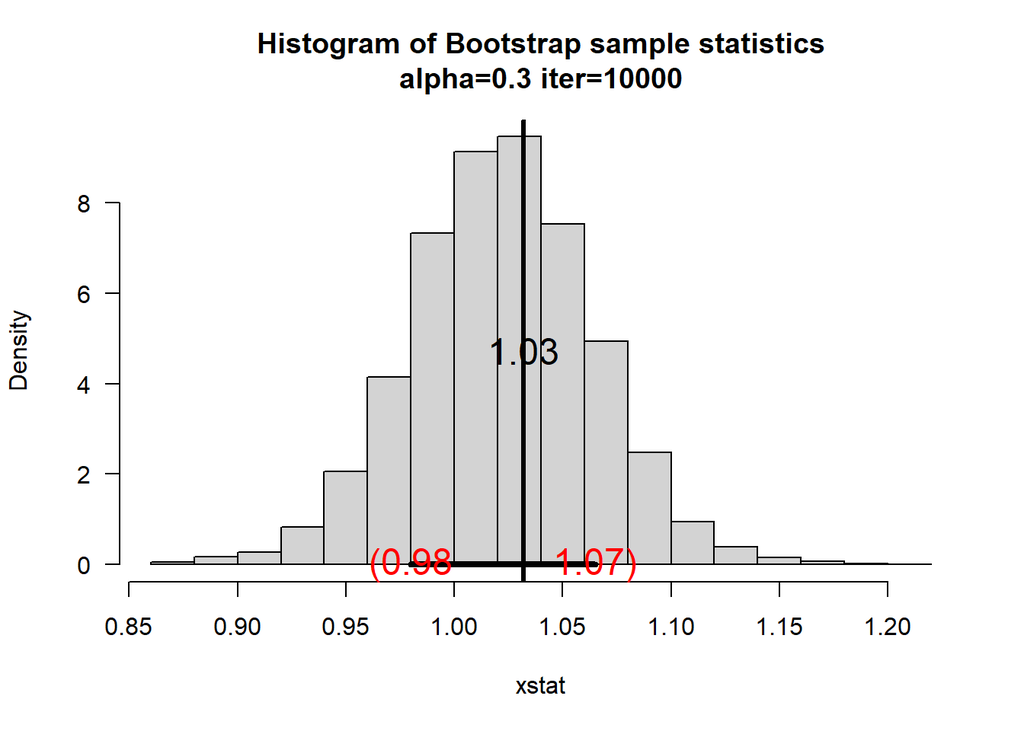

```r
set.seed(39)
sam=rnorm(25,mean=25,sd=10)
myboot2(sam, iter = 10000, alpha = 0.30, fun = "meandian")
```

The 70% interval estimate for the population mean/median is 0.98 to 1.07.

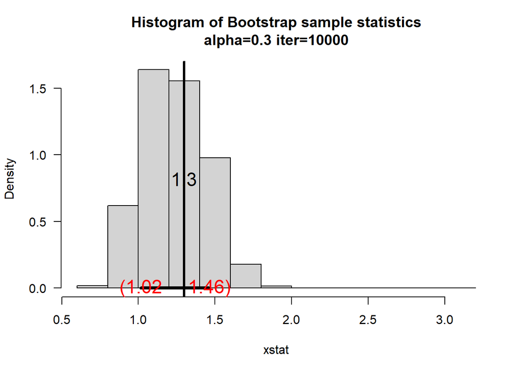

```r
set.seed(30)
sam=rchisq(20,df=3)
myboot2(sam, iter = 10000, alpha = 0.30, fun = "meandian")
```

The 70% interval estimate for the population mean/median is 1.02 to 1.46.

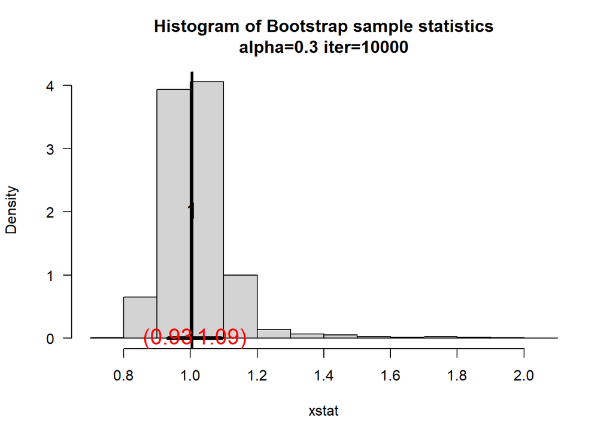

```r
set.seed(40)
sam=rgamma(30,shape=2,scale=3)
myboot2(sam, iter = 10000, alpha = 0.30, fun = "meandian")
```

The 70% interval estimate for the population mean/median is 0.93 to 1.09.

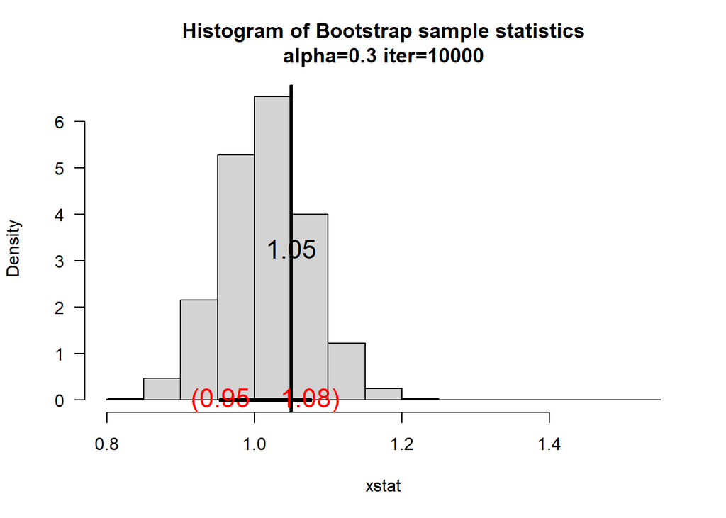

```r
set.seed(10)
sam=rbeta(20,shape1=3,shape2=4)
myboot2(sam, iter = 10000, alpha = 0.30, fun = "meandian")
```

The 70% interval estimate for the population mean/median is 0.95 to 1.08.

## Task 6

```r
#?distributions()
```

Using the Cauchy distribution:

```r
sam=rcauchy(20, location = 2, scale =3)
```

The mean:

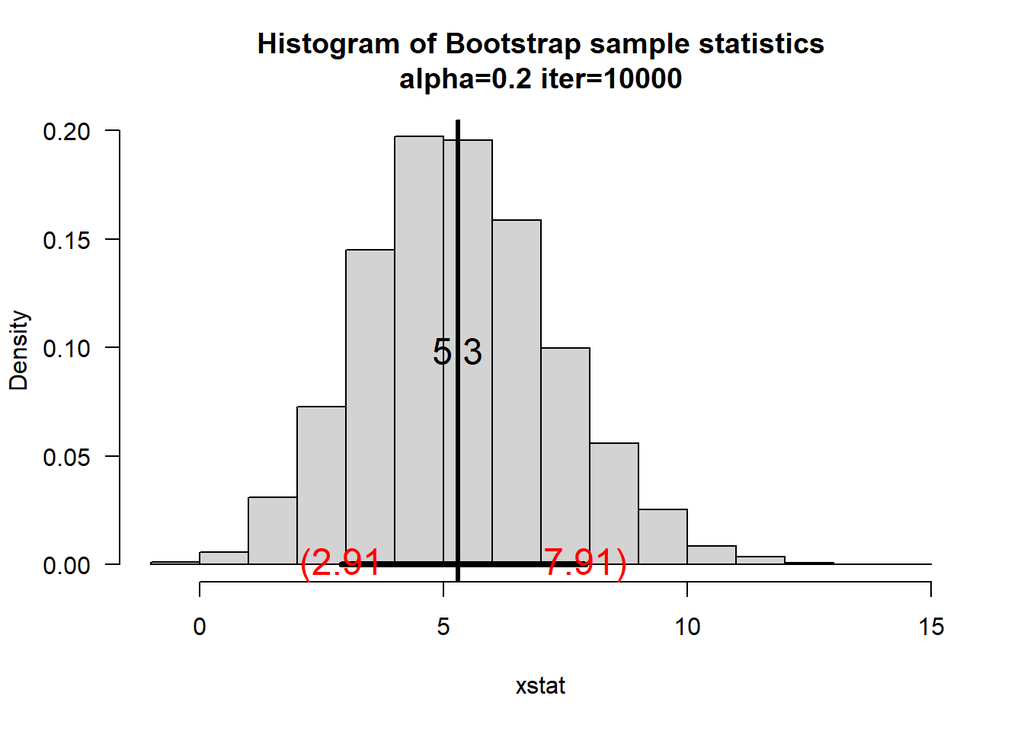

```r
myboot2(sam, iter = 10000, alpha = 0.20, fun = "mean")
```

The variance:

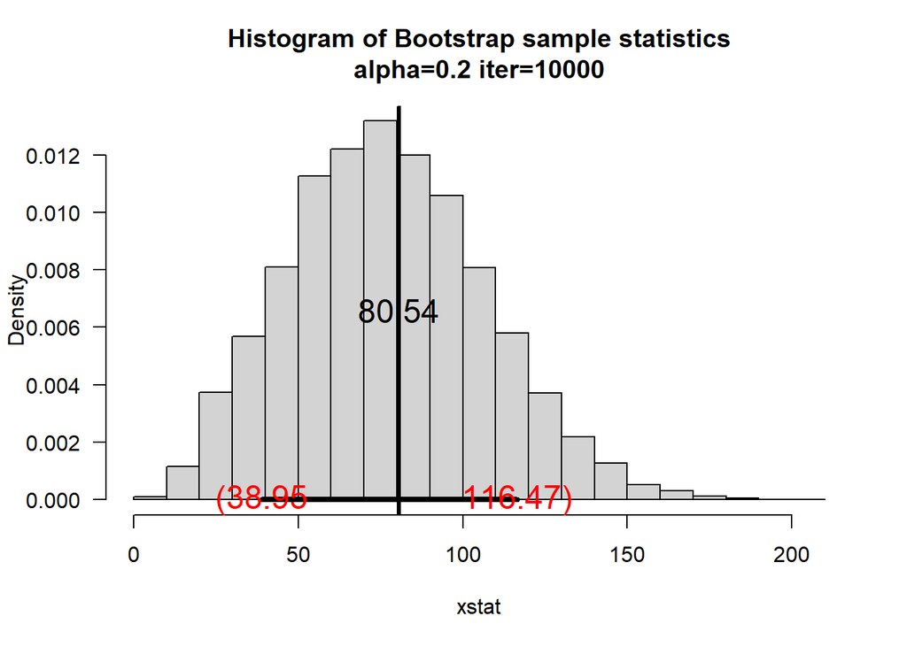

```r
myboot2(sam, iter = 10000, alpha = 0.20, fun = "var")
```

Using the F distribution:

```r
sam = rf(20, df1 =4, df2 = 2)
```

The mean:

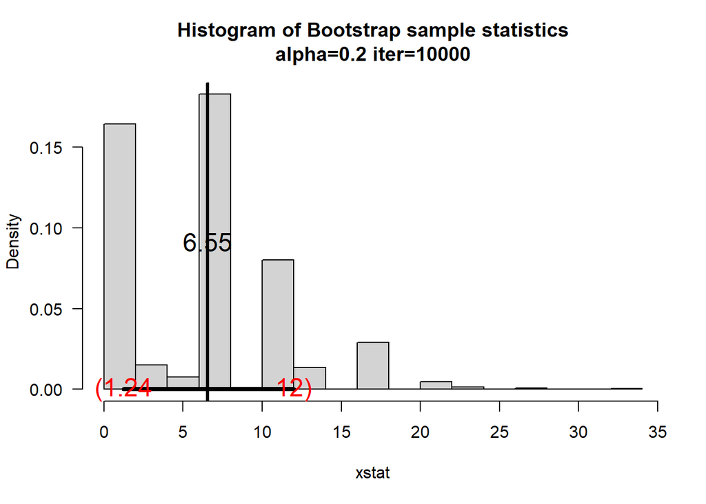

```r
myboot2(sam, iter = 10000, alpha = 0.20, fun = "mean")
```

The variance:

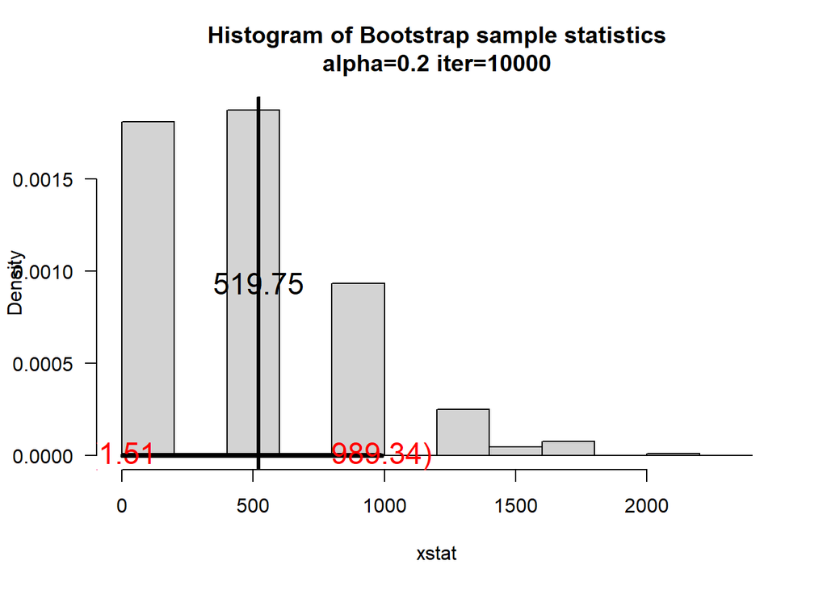

```r
myboot2(sam, iter = 10000, alpha = 0.20, fun = "var")
```

Using the log-normal distribution:

```r
sam = rlnorm(20, meanlog=0.5, sdlog=2)
```

The mean:

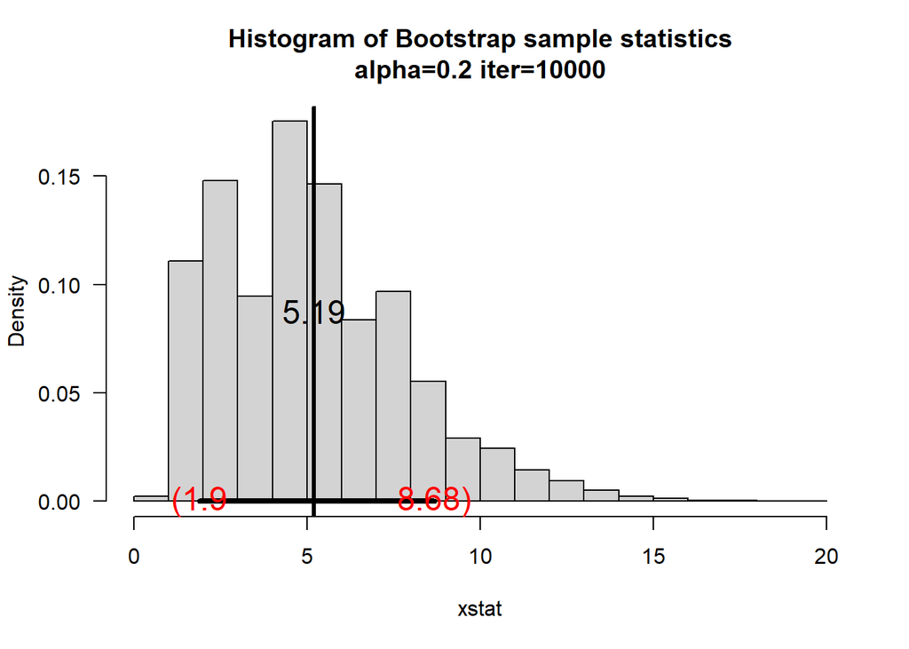

```r
myboot2(sam, iter = 10000, alpha = 0.20, fun = "mean")
```

The variance:

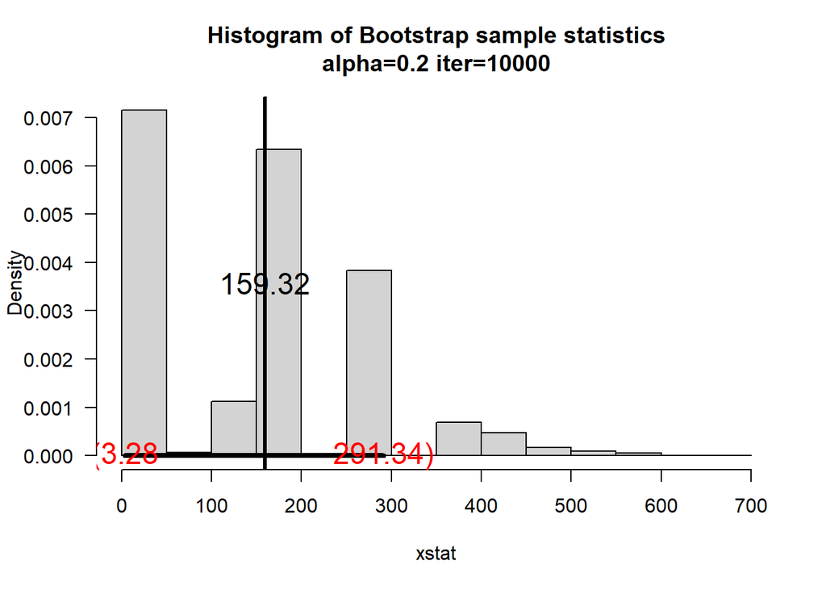

```r
myboot2(sam, iter = 10000, alpha = 0.20, fun = "var")
```

Using the Student t Distribution:

```r
sam = rt(20, df = 3)
```

The mean:

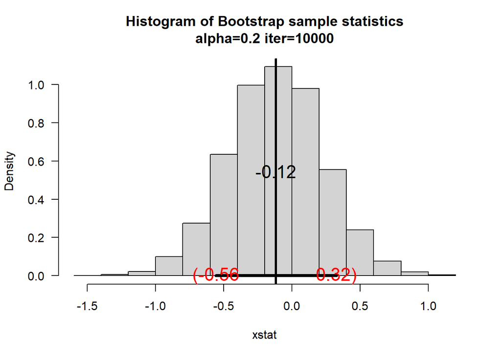

```r
myboot2(sam, iter = 10000, alpha = 0.20, fun = "mean")
```

The variance:

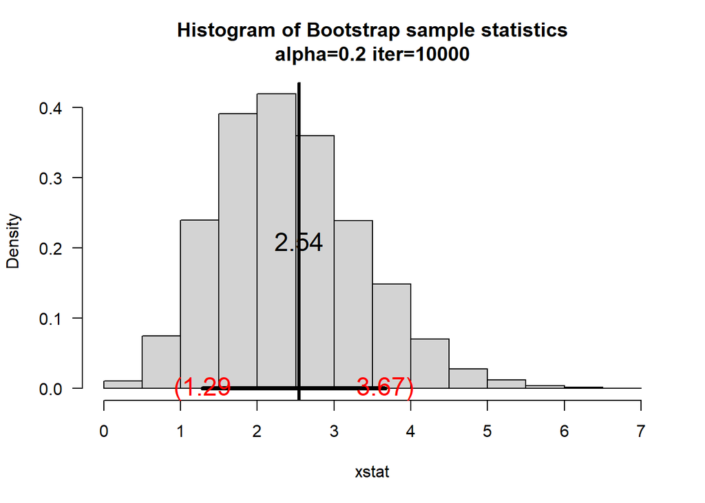

```r
myboot2(sam, iter = 10000, alpha = 0.20, fun = "var")
```

## Task 7

```r
set.seed(68)
sam=rnorm(20,mean=10,sd=4)
```

Inter-quartile range:

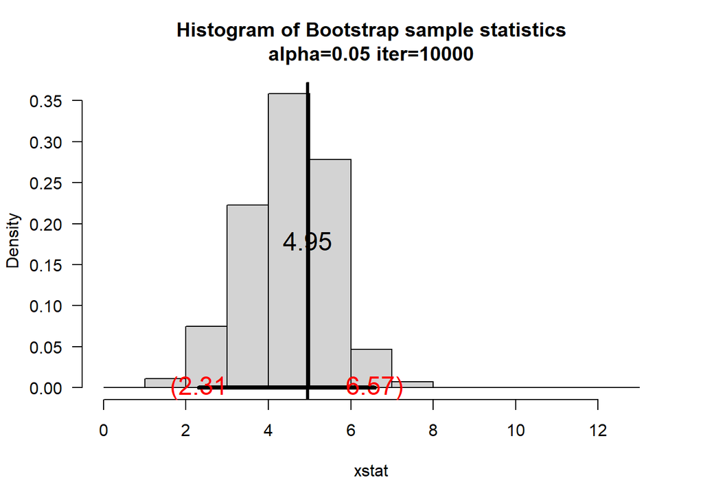

```r
myboot2(sam, iter = 10000, alpha = 0.05, fun = "IQR")
```

Standard deviation:

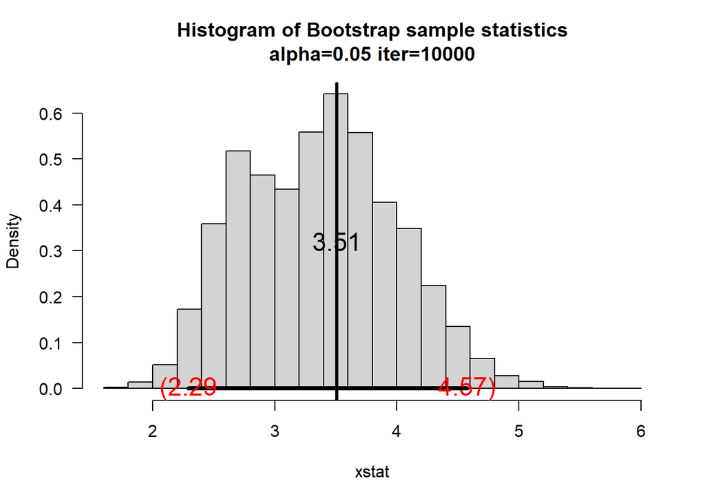

```r
myboot2(sam, iter = 10000, alpha = 0.05, fun = "sd")
```

Calculating the 95% confidence interval using theory:

```r
set.seed(68)
sam=rnorm(20,mean=10,sd=4)
```

```r
ybar = mean(sam)
sd =4
sqrtn = sqrt(20)
zalph2 = qnorm(1-0.05/2,mean=0,sd=1)
L = ybar - zalph2*sd/sqrtn
U = ybar + zalph2*sd/sqrtn
L
```

```
## [1] 8.706266
```

```r
U
```

```
## [1] 12.21236
```

The 95% confidence interval for the mean using the theory is 8.7063 to 12.2124.

Calculing the 95% confidence interval using myboot2:

```r
obj = myboot2(sam, iter = 10000, alpha = 0.05, fun = "mean")
```

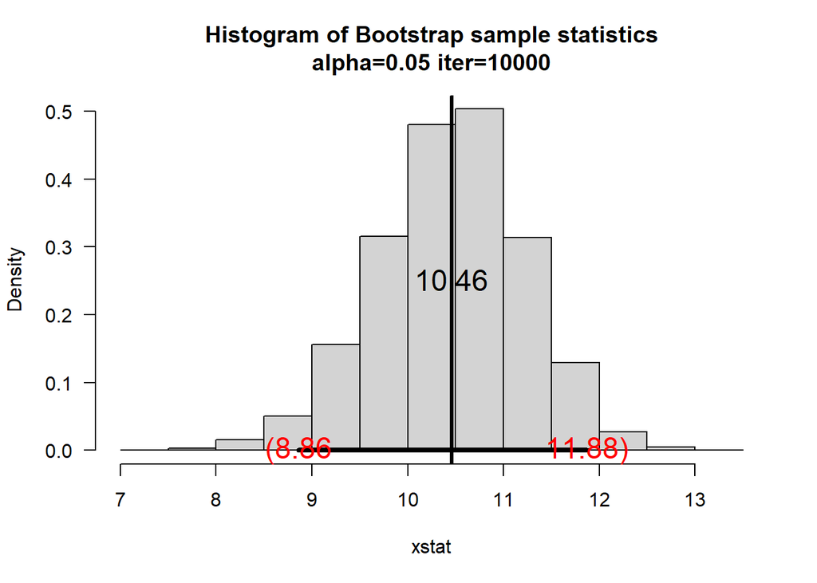

The 95% confidence interval for the mean using myboot2() is:

```r
obj$ci
```

```
##      2.5%     97.5%
##  8.862478 11.878680
```

The confidence intervals calculated using different methods are comparable to each other. The interval using myboot2 is smaller by roughly 0.2 on the lower tail and 0.3 on the upper tail.

## Task 8

```r
ddt = read.csv("DDT.csv")
obj = MATH4753GROE002::myboot2dg(x =ddt$DDT)
```

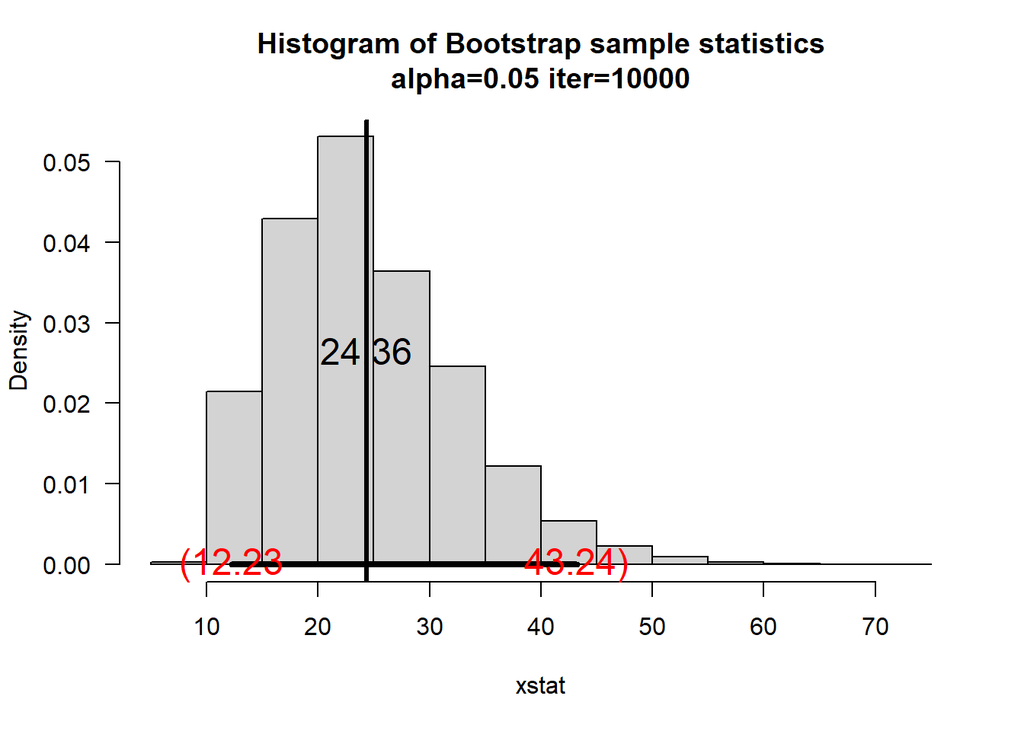